# Lab2 - GWAS - genome-wide association study

Sami Saarenpää

22 Sep 20

# 1 Lab info

We will will use the data from Saw et.al (2017) to illustrate the genome-wide association studies (GWAS). We will map the genetic determinants of cholesterol levels within three Southeast Asian populations.

In this part of the lab we will give you the output of the R code directly. Instead the focus is to understand what type of data one could get out of variant analysis and genome-wide association studies (GWAS).

Use the provided template to answer the questions!

## 1.1 What is GWAS?

Genome-wide association (GWA) studies scan an entire species genome for association between up to millions of SNPs/indels and a given trait of interest. Notably, the trait of interest can be virtually any sort of phenotype ascribed to the population, be it qualitative (e.g. disease status) or quantitative (e.g. height).

Essentially, given p SNPs and n samples or individuals, a GWAS will fit p independent univariate linear models, each based on n samples, using the genotype of each SNP as predictor of the trait of interest. The significance of association (P-value) in each of the p tests is determined from the coefficient estimate of the corresponding SNP (technically speaking, the significance of association is P(|H_0: =0) ). It’s necessary to adjust the resulting P-values using multiple hypothesis testing methods such as Bonferroni, Benjamini-Hochberg or false discovery rate (FDR).

## 1.2 Data

Data is from Saw et.al (2017): https://www.nature.com/articles/s41467-017-00413-x.

There is a mixed population of 316 Chinese, Indian and Malay in the study. These individuals were characterized using high-throughput SNP-chip sequencing, transcriptomics and lipidomics. In this data, we have >2.5 million SNP markers as well as cholesterol levels which we will search for associations.

## 1.3 General workflow

These steps are already made for you, but to get the overall picture ->

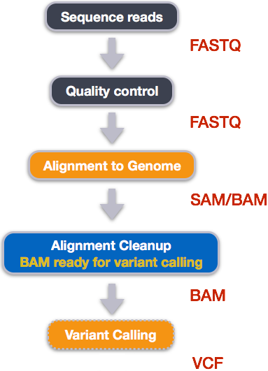

### 1.3.1 Steps after SNP calling

So, lets start where the SNPs are already called. We also have some metadata along with our samples (lipid measurements on each patient and their country). We lack all info on some of the samples, so we only keep complete cases (a quite common situation..).

### 1.3.2 Pre-processing

Since we are working with huge date, it would be in order to conduct some filtering prior to analysis. Lets: - discarding SNPs with call rate < 1 or Minor-allele frequency (MAF) < 0.1 - discarding samples with call rate < 100%, IBD kinship coefficient > 0.1 or inbreeding coefficient |F| > 0.1

Again, this is already made for you… Just keep in mind that various filtering steps are usually conducted to limit the size of the data, both for computational and statistical reasons.

## 1.4 Analysis

### 1.4.1 Principal component analysis (PCA)

Let’s use a standard go-to visualization method for high dimensional data as an exploratory look of our samples.

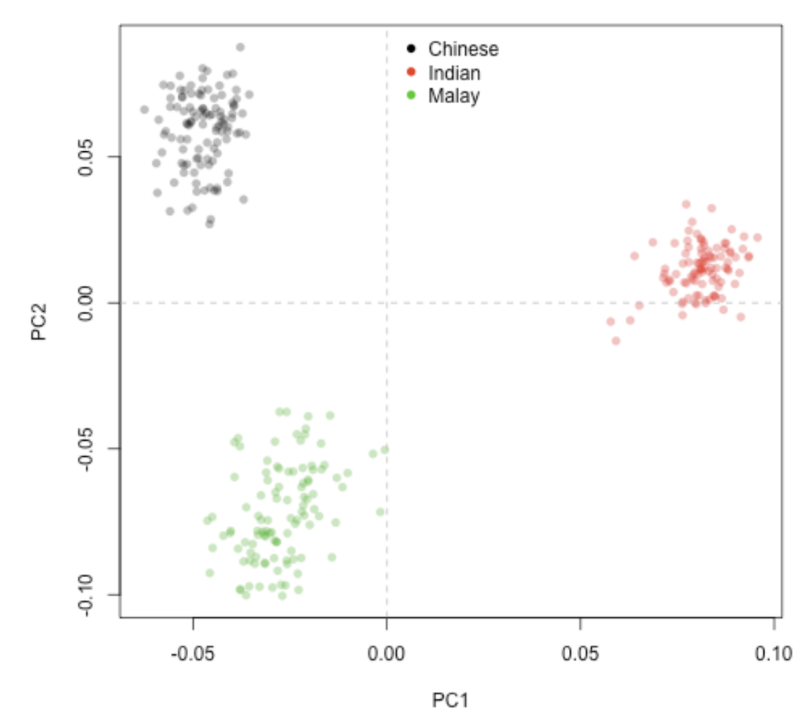

PCA

Q1: Explain the result

```r
#Add answer here
```

### 1.4.2 GWAS

Let’s now perform our GWAS study. In the information we have 282 different lipids, lets choose to make the cholesterol levels our target of interest.

```r
# Choose trait for association analysis, use colnames(genData$LIP) for listing
# NOTE: Ignore the first column of genData$LIP (gender)
target <- "Cholesterol"

phenodata <- data.frame("id" = rownames(genData$LIP),
                        "phenotype" = scale(genData$LIP[,target]),
                        stringsAsFactors = F)

# Conduct GWAS (will take a long while)

#If the GWAA command doesn't work, uncomment:
#library(rstudioapi)
#if (Sys.getenv("RSTUDIO") == "1" && !nzchar(Sys.getenv("RSTUDIO_TERM")) &&
#    Sys.info()["sysname"] == "Darwin" && getRversion() >= "4.0.0") {
#  if(versionInfo()$version < "1.3.1056"){
#    parallel:::setDefaultClusterOptions(setup_strategy = "sequential")
#  }
#}

start <- Sys.time()
GWAA(genodata = genData$SNP, phenodata = phenodata, filename = paste(target, ".txt", sep = ""))
Sys.time() - start # benchmark
```

For visualization of our results, we will use a “Manhattan plot”.

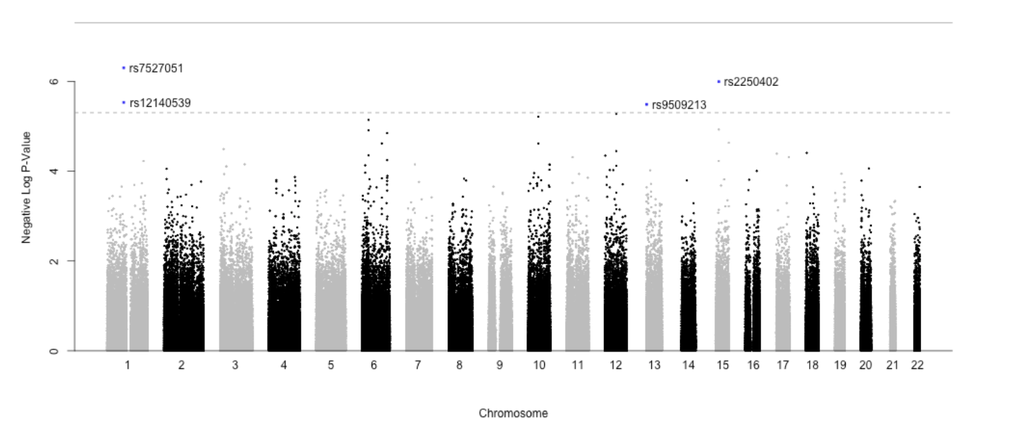

Manhattan plot

```r
# Manhattan plot
GWASout <- read.table(paste(target, ".txt", sep = ""), header = T,
                      colClasses = c("character", rep("numeric",4)))
GWASout$type <- rep("typed", nrow(GWASout))
GWASout$Neg_logP <- -log10(GWASout$p.value)
GWASout <- merge(GWASout, genData$MAP[,c("SNP", "chr", "position")])
GWASout <- GWASout[order(GWASout$Neg_logP, decreasing = T),]

png(paste(target, ".png", sep = ""), height = 500,width = 1000)
GWAS_Manhattan(GWASout)
dev.off()
```

Q2: How many significant SNPs do you see? And if so, what chromosomes are those on?

```r
#Add answer here
```

Lets also include a little sanity check of our result by using a Q-Q plot. Here, we contrast the distribution of the resulting p-values against that expected by chance. If the two are identical, we get a x=y line. If our method to obtain our result are sound, we should in theory get a x=y line with a few deviating values suggestive of association. Otherwise, we might have confounding factors that cause problems for our approach.

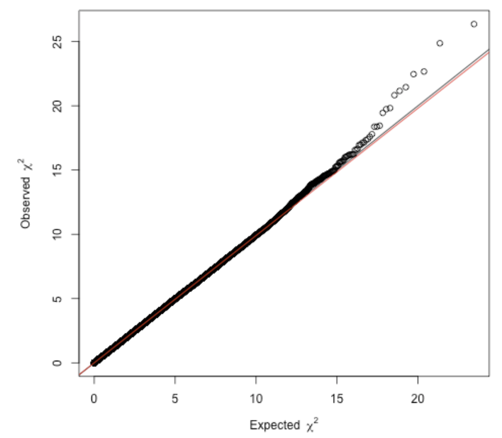

Q-Q plot

Q3: What is your interpretation of the Q-Q plot?

## 1.5 Functional interpretation

Each SNP is identified via an ID, lets take a look at the identified significant variants. You an search e.g https://www.ncbi.nlm.nih.gov/snp/ with this ID as input to find out information about the variant.

Q4: Is there any variant that are within a gene? Can you find any potential biological association of interest with regards to cholesterol?

```r
#Add answer here
```

## 1.6 Acknowledgement

Tutorial is adapted from GWAStutorial by Francisco Lima.